# AEDV - Lista 1 - Atividade B: Gapminder

# Mundo em 2007

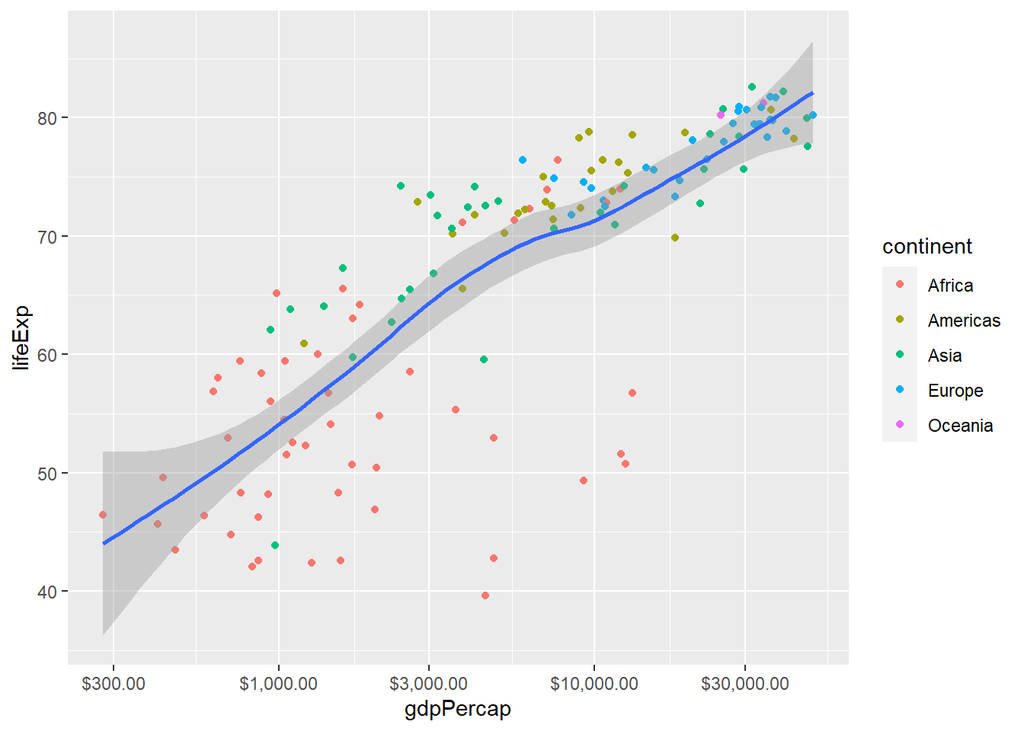

```r
g2 = ggplot(subset(gapminder, year == 2007), aes(x = gdpPercap, y = lifeExp)) +
  geom_point(aes(color = continent)) +
  geom_smooth() +
  scale_x_log10(labels = scales::dollar)

g2
```

Em seguida, achei que seria interessante configurar o tamanho dos pontos (“size”) para representar a população dos países. Configurei esse parâmetro dentro da função “geom_point” para que ele não inteferisse na legenda.

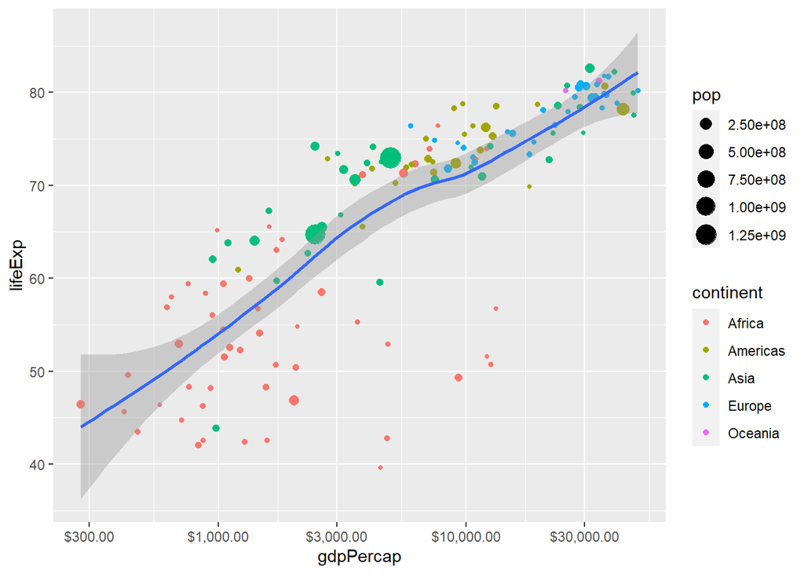

```r
g2 = ggplot(subset(gapminder, year == 2007), aes(x = gdpPercap, y = lifeExp)) +
  geom_point(aes(color = continent, size = pop)) +
  geom_smooth() +
  scale_x_log10(labels = scales::dollar)

g2
```

Após isso, retirei a margem de erro da linha de regressão com o argumento “se = F” e colori-a de preto para destacá-la.

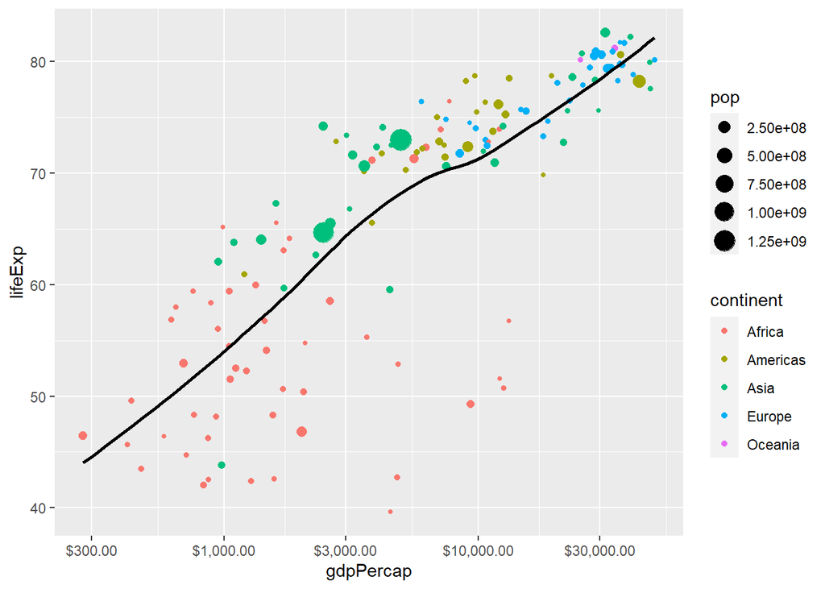

```r
g2 = ggplot(subset(gapminder, year == 2007), aes(x = gdpPercap, y = lifeExp, label = country)) +
  geom_point(aes(color = continent, size = pop)) +
  geom_smooth(se = F, color = "black") +
  scale_x_log10(labels = scales::dollar)

g2
```

Agora, começo a personalização em si do gráfico. Em primeiro lugar, configurei os textos utilizando a função “labs” e a função “scale_size” para alterar o formato dos valores da legenda de tamanho de notação científica para números. Além disso, importei a biblioteca “ggrepel” para inserir rótulos nos pontos mais isolados do gráfico.

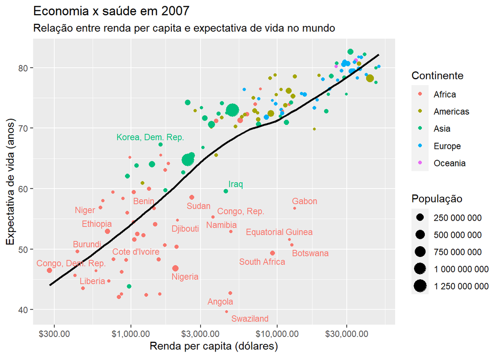

```r
if(!require(ggrepel)) install.packages("ggrepel", repos = "http://cran.us.r-project.org")
library(ggrepel)

g2 = g2 +
  labs(x = "Renda per capita (dólares)", y = "Expectativa de vida (anos)", title = "Economia x saúde em 2007", subtitle = "Relação entre renda per capita e expectativa de vida no mundo", size = "População", color = "Continente") +
  scale_size(labels = scales::number) +
  geom_text_repel(size = 3, max.overlaps = 5, aes(color = continent), show.legend = F)

g2
```

A seguir, comecei a mexer com as cores do gráfico. Para isso, importei a biblioteca “RColorBrewer”.

```r
if(!require(RColorBrewer)) install.packages("RColorBrewer", repos = "http://cran.us.r-project.org")
library(RColorBrewer)
```

Agora, bastou escolher uma paleta de cores para meu gráfico.

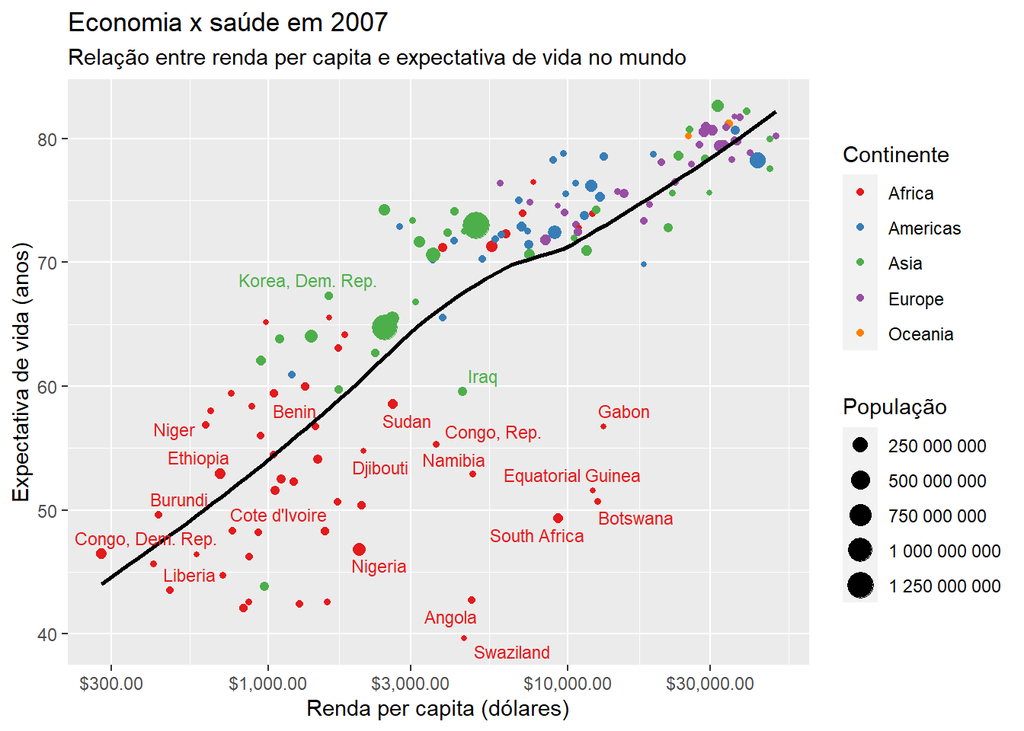

```r
g2 = g2 + scale_color_brewer(palette = "Set1")

g2
```

Por fim, para configurar o tema, carreguei a biblioteca “ggthemes” e selecionei uma das opções.

```r
if(!require(ggthemes)) install.packages("ggthemes", repos = "http://cran.us.r-project.org")
library(ggthemes)

g2 = g2 + theme_clean()
```

E o meu gráfico final ficou assim:

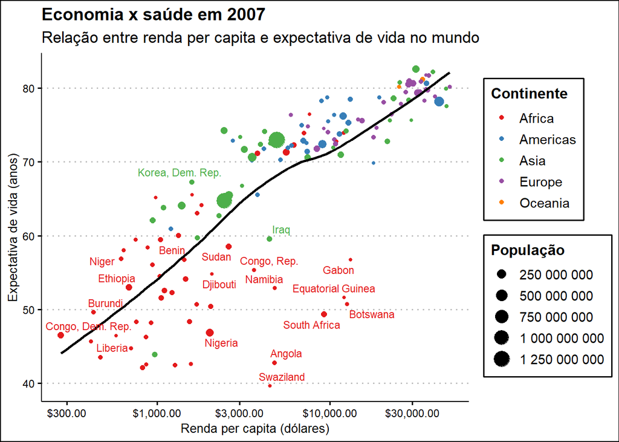

```r
g2
```

# Continentes em 2007

Em segundo lugar, decidi “separar” esse gráfico anterior por continente. Para isso, adicionei uma camada “facet_wrap”:

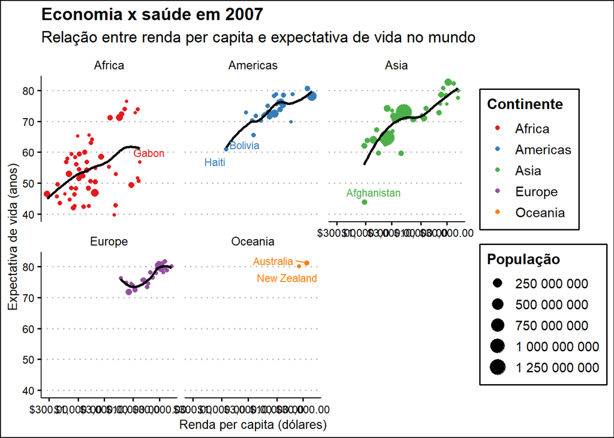

```r
g3 = g2 + facet_wrap(~continent)

g3
```

Entretanto, a linha de regressão perdeu um pouco da sua relevância aqui, os rótulos do eixo x estão totalmente mal formatados e a legenda das cores se tornou inútil. Assim, eliminei as linhas de regressão, configurei os textos do eixo x com a função “theme” e apaguei a legenda dos continentes com a função “guides”.

```r
g3 = ggplot(subset(gapminder, year == 2007), aes(x = gdpPercap, y = lifeExp, size = pop, color = continent, label = country)) +
  geom_point() +
  scale_x_log10(labels = scales::dollar) +
  labs(x = "Renda per capita (dólares)", y = "Expectativa de vida (anos)", title = "Economia x saúde em 2007 por continente", subtitle = "Relação entre renda per capita e expectativa de vida no mundo", size = "População", color = "Continente") +
  scale_size(labels = scales::number) +
  geom_text_repel(size = 3, max.overlaps = 10, aes(color = continent)) +
  scale_color_brewer(palette = "Set1") +
  theme_clean() +
  facet_wrap(~continent) +
  theme(axis.text.x = element_text(angle = 90, hjust = 1)) +
  guides(color = "none")
```

E o resultado final foi este:

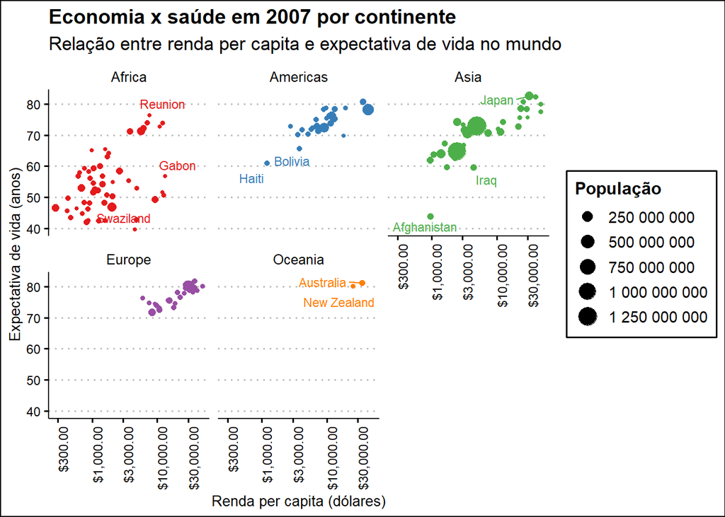

```r
g3
```

# Mundo por ano

Por último, resolvi me inspirar um pouco no Hans Rosling e criar um gráfico que exibe essa mesma relação renda per capita x expectativa de vida, mas para todos os anos da base de dados. Para isso, comecei gerando um gráfico de dispersão:

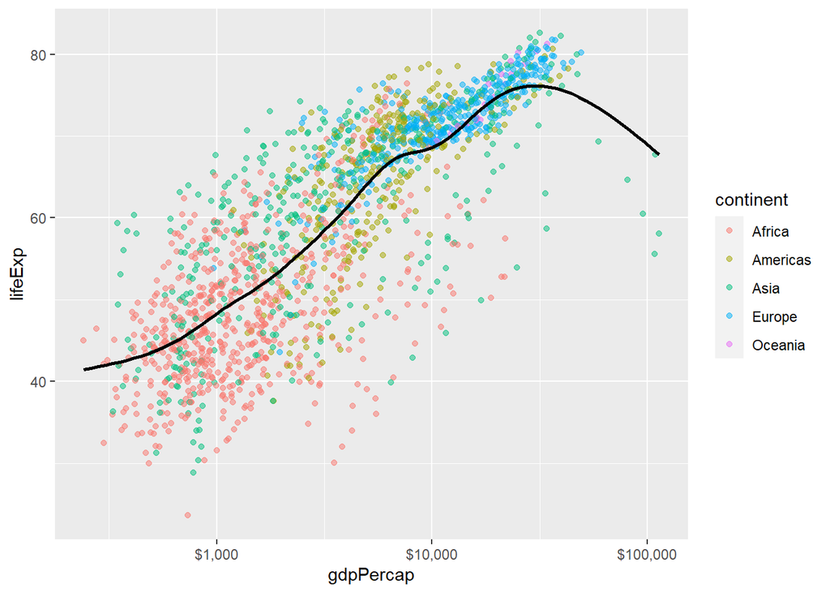

```r
g4 = ggplot(gapminder, aes(x = gdpPercap, y = lifeExp, color = continent)) +
  geom_point(alpha = 0.5) +
  geom_smooth(se = F, color = "black") +
  scale_x_log10(labels = scales::dollar)

g4
```

Em seguida, adicionei as camadas por ano com a função “facet_wrap”.

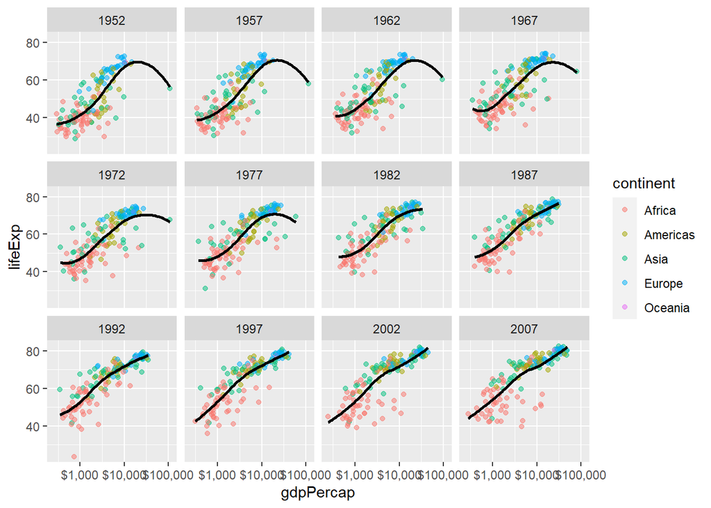

```r
g4 = g4 + facet_wrap(~year)

g4
```

Para terminar, bastou ajeitar novamente os textos, as cores e o tema e pronto!

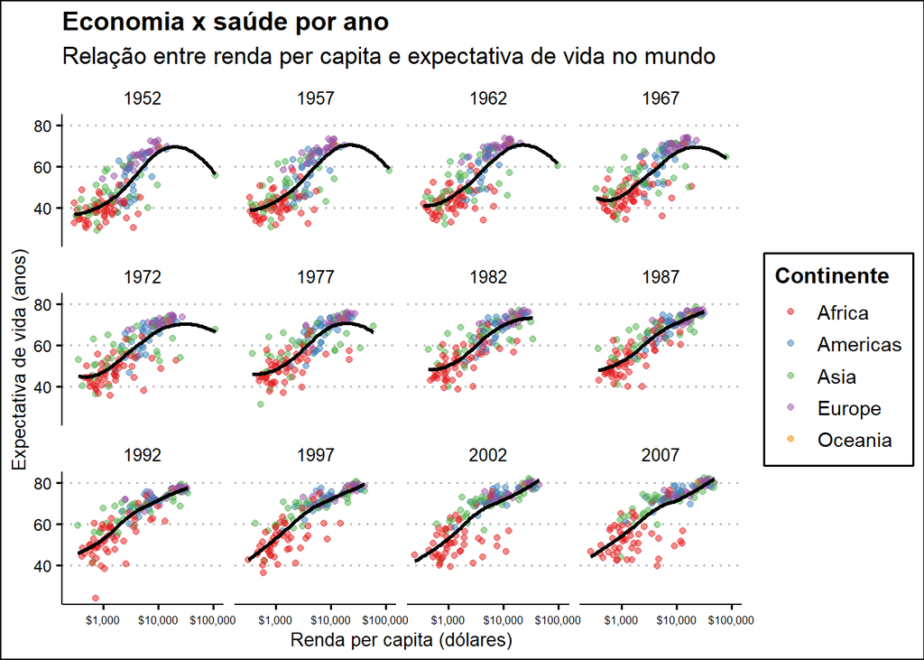

```r
g4 = g4 +
  labs(x = "Renda per capita (dólares)", y = "Expectativa de vida (anos)", title = "Economia x saúde por ano", subtitle = "Relação entre renda per capita e expectativa de vida no mundo", color = "Continente") +
  theme_clean() +
  theme(axis.text.x = element_text(size = 6)) +
  scale_color_brewer(palette = "Set1")

g4
```